# Plotting Data

Edward A. Roualdes

# Categorical Data

## Visualizing Categorical Variables

With categorial data we can make **bar charts**.

```r
suppressMessages(library(tidyverse))
suppressMessages(library(openintro))
data(email)
ggplot(data = email, aes(number)) +
    geom_bar() +
    labs(title = "email 'Number' Frequency")
```

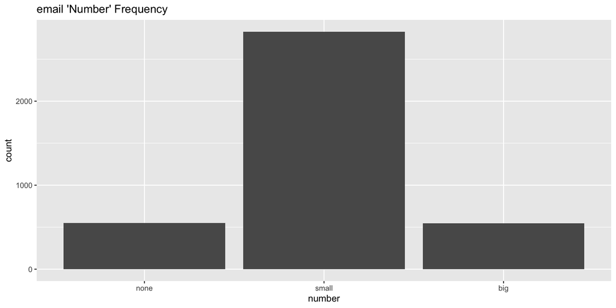

## `county`

Recall the county data set? How big?

```r
data(county)
tail(county[, c("state", "name")])
```

```
# A tibble: 6 × 2
  state   name
  <fct>   <chr>
1 Wyoming Sublette County
2 Wyoming Sweetwater County
3 Wyoming Teton County
4 Wyoming Uinta County
5 Wyoming Washakie County
6 Wyoming Weston County
```

## `county`

Frequency table of county data.

```r
table(county$state)
```

```
             Alabama               Alaska              Arizona
                  67                   29                   15
            Arkansas           California             Colorado
                  75                   58                   64
         Connecticut             Delaware District of Columbia
                   8                    3                    1
             Florida              Georgia               Hawaii
                  67                  159                    5
               Idaho             Illinois              Indiana
                  44                  102                   92
                Iowa               Kansas             Kentucky
                  99                  105                  120
           Louisiana                Maine             Maryland
                  64                   16                   24
       Massachusetts             Michigan            Minnesota
                  14                   83                   87
         Mississippi             Missouri              Montana
                  82                  115                   56
            Nebraska               Nevada        New Hampshire
                  93                   17                   10
          New Jersey           New Mexico             New York
                  21                   33                   62
      North Carolina         North Dakota                 Ohio
                 100                   53                   88
            Oklahoma               Oregon         Pennsylvania
                  77                   36                   67
        Rhode Island       South Carolina         South Dakota
                   5                   46                   66
           Tennessee                Texas                 Utah
                  95                  254                   29
             Vermont             Virginia           Washington
                  14                  133                   39
       West Virginia            Wisconsin              Wyoming
                  55                   72                   23
```

## `county`

Bar chart of county data.

```r
(pl <- ggplot(data = county, aes(state)) +
     geom_bar() +
     labs(title = "?", x = "States"))
```

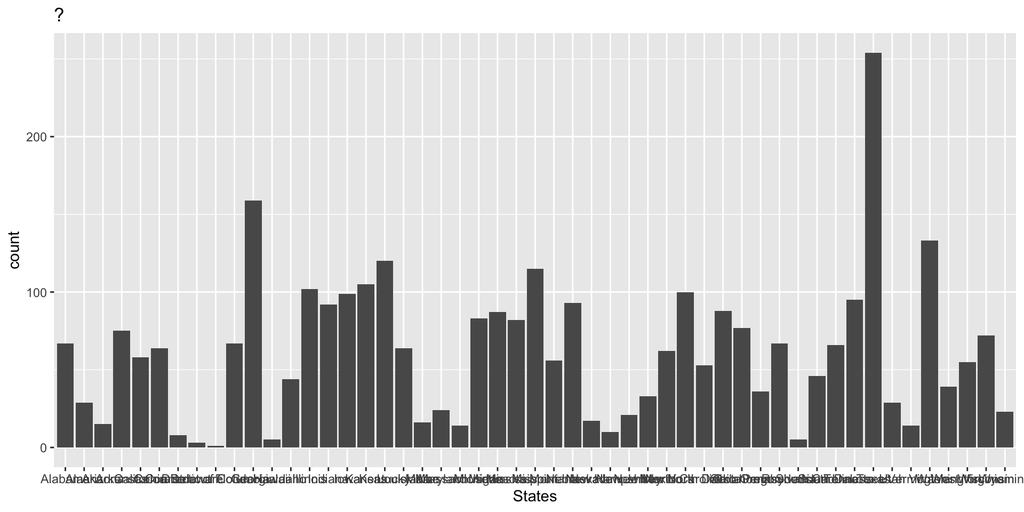

## `county`

```r
pl + theme(axis.text.x = element_text(angle = 45,
    hjust=1))
```

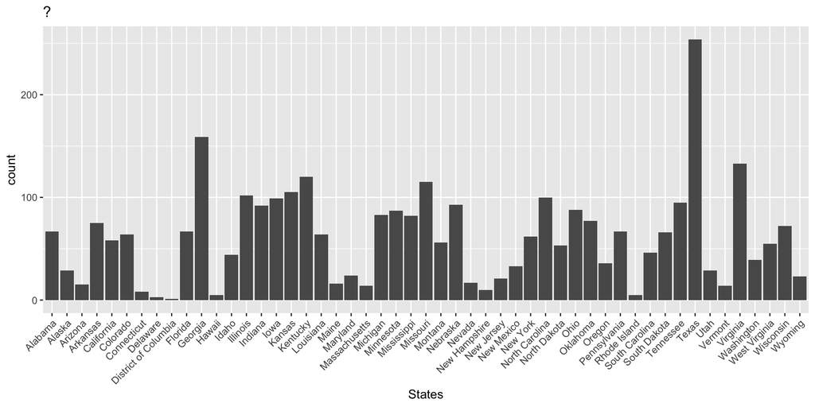

# Numerical Data

## Towards Histograms

What do we give up by finding a mean? Consider `county`

```r
mean(county$per_capita_income, na.rm = TRUE)
```

```
[1] 26093.12
```

```r
min(county$per_capita_income, na.rm = TRUE)
```

```
[1] 10466.84
```

```r
max(county$per_capita_income, na.rm = TRUE)
```

```
[1] 69532.86
```

## Histograms

A histogram helps summarize tails of the data:

```r
(p <- ggplot(data = county, aes(per_capita_income)) +
     geom_histogram(bins = 21) +
     labs(x = "Per capita income"))
```

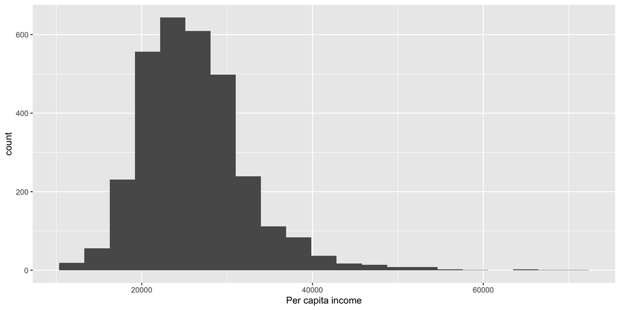

## Histograms, in words

Think of each observation as belonging to a **bin**. These binned observations are plotted as bars to form a histogram. That is, the height of each bar depicts the number of observations within each bin.

## Histograms, picking bins

Since the researcher has to choose the bin width, we should learn the difference between bins that are too small and bins that are too wide.

## Histograms, too many

Extremely small bins

```r
ggplot(data = county, aes(per_capita_income)) +
    geom_histogram(binwidth = 3) +
    labs(x = "Per capita income")
```

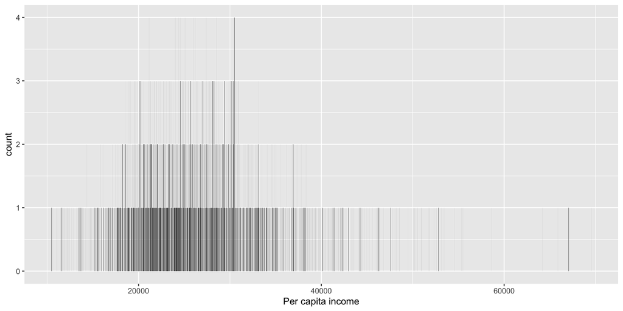

## Histograms, too few

Extremely large bins

```r
ggplot(data = county, aes(per_capita_income)) +
    geom_histogram(binwidth = 80000) +
    labs(x = "Per capita income")
```

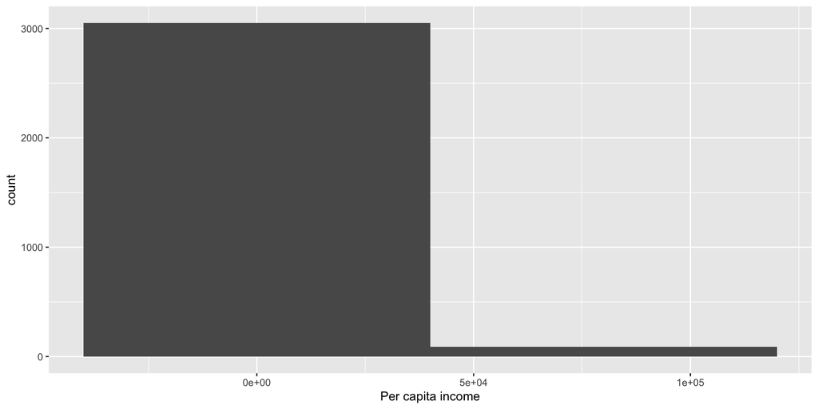

## Histograms, by group

Compare chicken weights by diet.

```r
ggplot(data=ChickWeight, aes(weight)) +
    geom_histogram(bins = 21) +
    facet_wrap(Diet ~ ., ncol = 1)
```

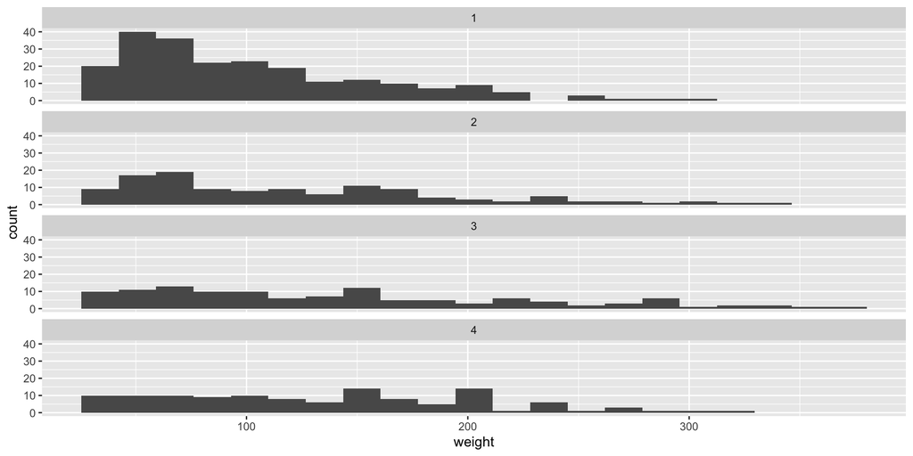

## Histograms, keywords

- **right skewed**. When data trail to the right and have a longer right tail, the shape is said to be right skewed.
- **left skewed**. Data with the reverse characteristic – a long, thin tail to the left – are said to be left skewed.
- **symmetric**. Data that show roughly equal tails in both directions are called symmetric.

## Histograms, and measures of center

Where is the mean on a histogram? Median?

```r
mn <- mean(county$per_capita_income, na.rm = TRUE)
mdn <- median(county$per_capita_income, na.rm = TRUE)
p + geom_vline(aes(xintercept=mn), color="red", size=1) +
    geom_vline(aes(xintercept=mdn), color="blue", size=1)
```

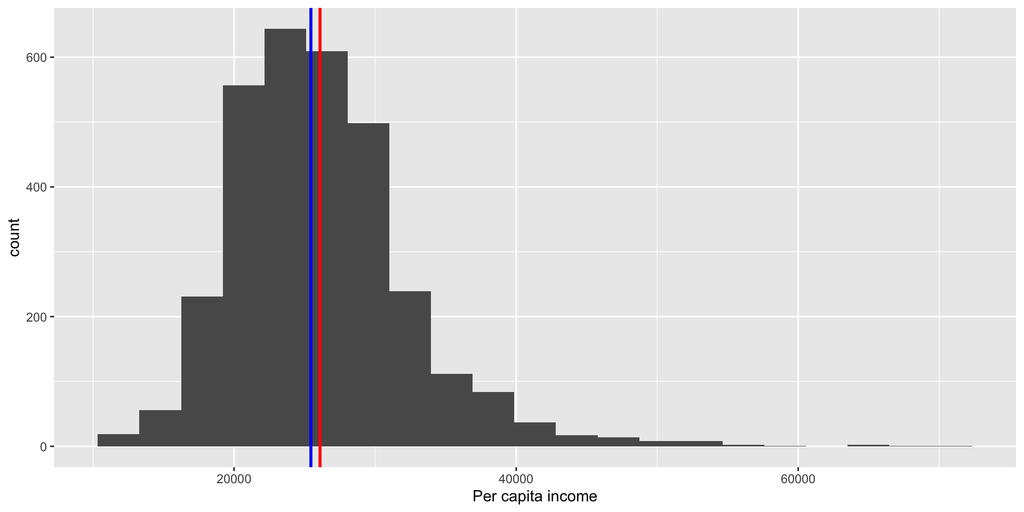

## Histograms, they tell us more

What more, other than the center of the data, do histograms tell us? Consider a histogram from the `email` data set.

```r
em <- mean(email$num_char)
ggplot(data=email, aes(num_char)) +
    geom_histogram(bins = 21) +
    geom_vline(aes(xintercept = em), color = "blue")
```

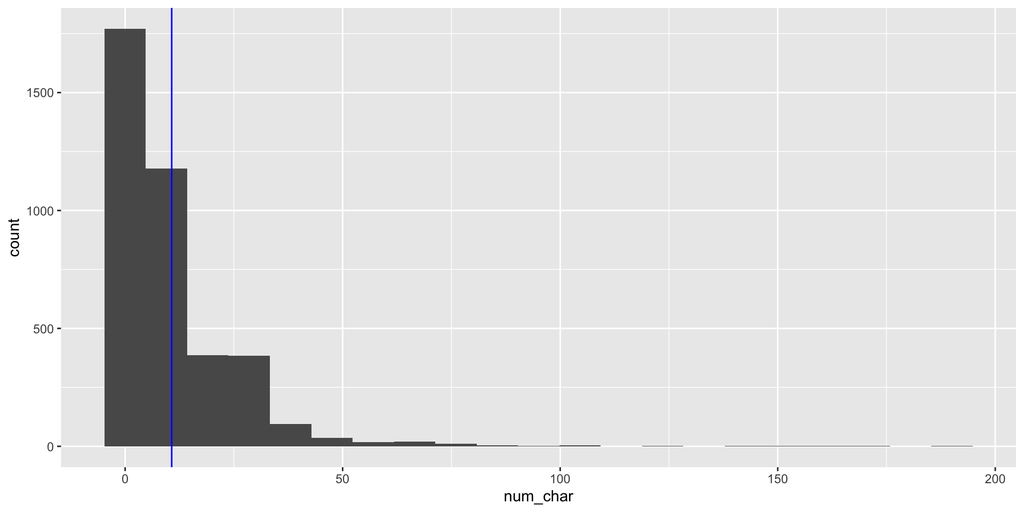

## Histograms, an ideal

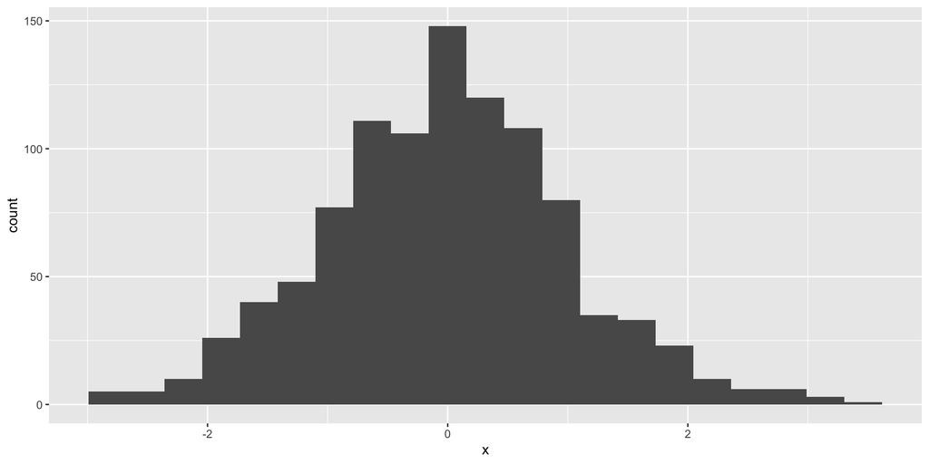

## Data Width, 1 standard deviation

Histograms naturally connect with **standard deviations**. If the data are **unimodal** (ish) and symmetric (ish), roughly 68% of the data will be within one standard deviation of the mean.

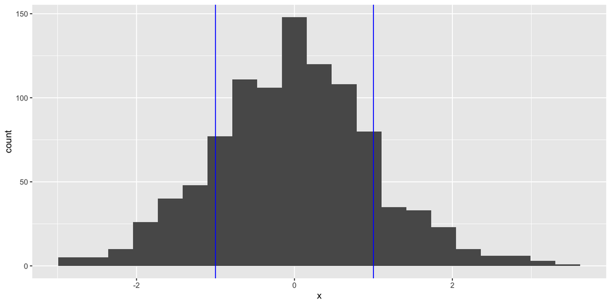

## Data Width, 2 standard deviations

If the data are **unimodal** (ish) and symmetric (ish), roughly 95% of the data will be within two standard deviations of the mean.

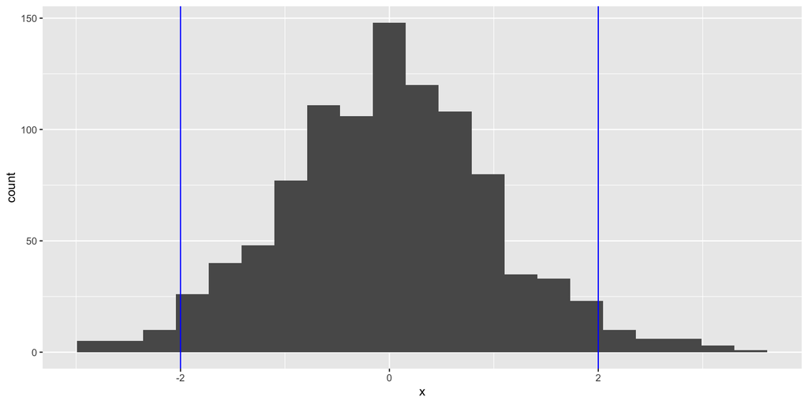

## Data Width, 3 standard deviations

If the data are **unimodal** (ish) and symmetric (ish), roughly 99.7% of the data will be within three standard deviations of the mean.

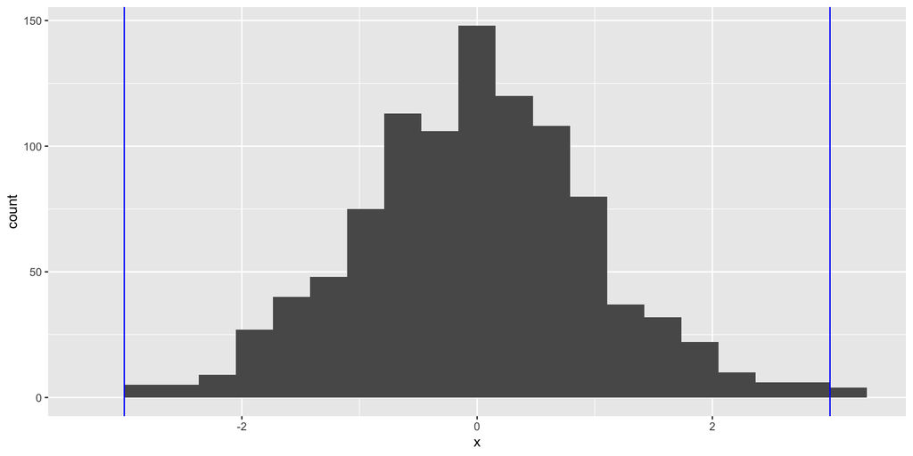

## Standard Deviations, be careful

Three different population distributions with the same (population) mean $\mu$ = 0 and (population) standard deviation $\sigma = 1$.

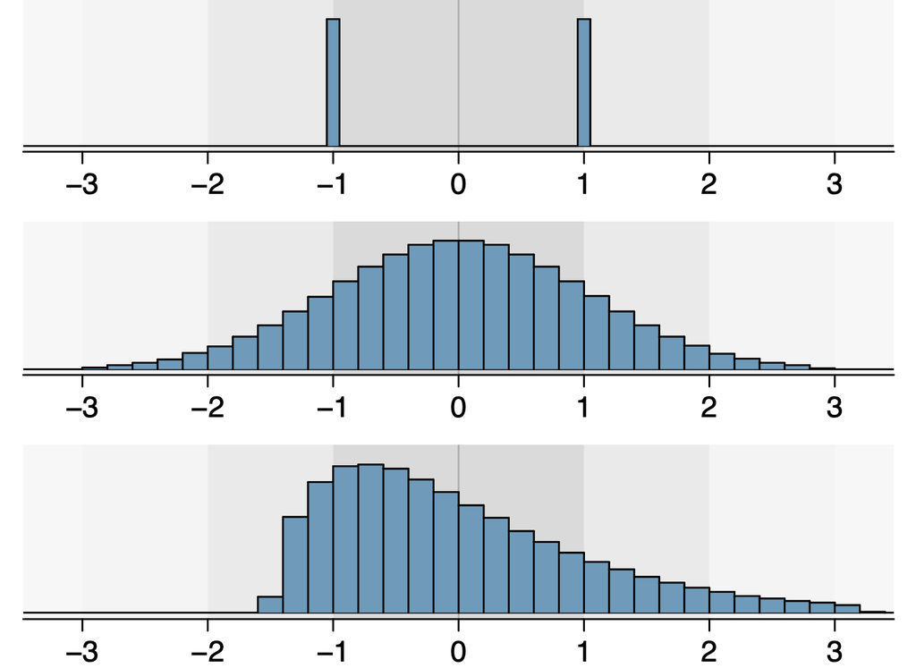

## Towards Box plots

We will use the data set `carnivora` found within the library `ape`.

```r
library(ape)
data(carnivora)
# ?carnivora
```

## recap: summary statistics

R will fairly easily produce six number summaries for us. Here’s the variable for average brain weight amongst male and female animals from the order Carnivora.

```r
summary(carnivora$SB)
```

```
   Min. 1st Qu.  Median    Mean 3rd Qu.    Max.
   1.00   15.68   33.75   56.43   57.17  459.50
```

## Box Plots

A **box plot** summarizes a data set using five (standard) statistics while also plotting unusual observations.

## Box Plot, explained

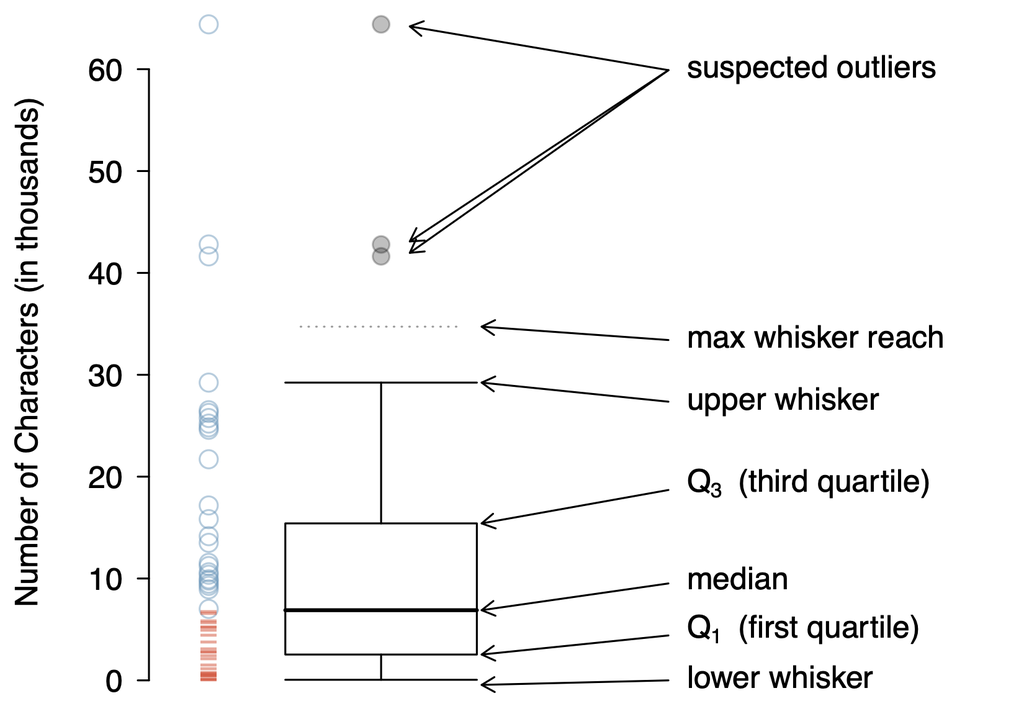

## Box Plot, carnivora example

```r
ggplot(data = carnivora, aes(Order, SB)) +
    geom_boxplot() +
    labs(y = "Average brain weight (g)",
         x = "Order")
```

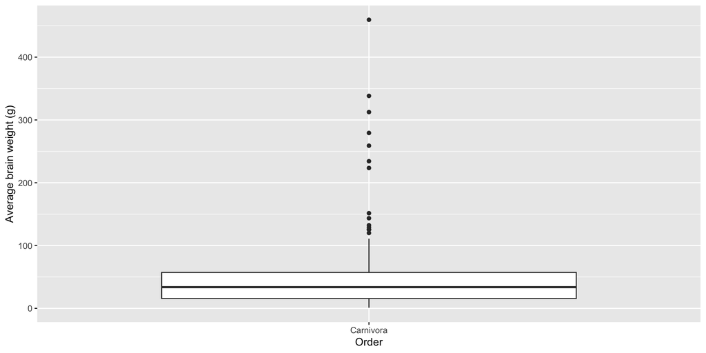

## Box Plot, better carnivora example

Have you seen some of the families in carnivora? From adorable, Ailuridae, to huge, [Ursidae](https://en.wikipedia.org/wiki/Bear).

```r
ggplot(data = carnivora, aes(Family, SB)) +
    geom_boxplot() +
    labs(x = "Family", y = "Average brain weight (g)")
```

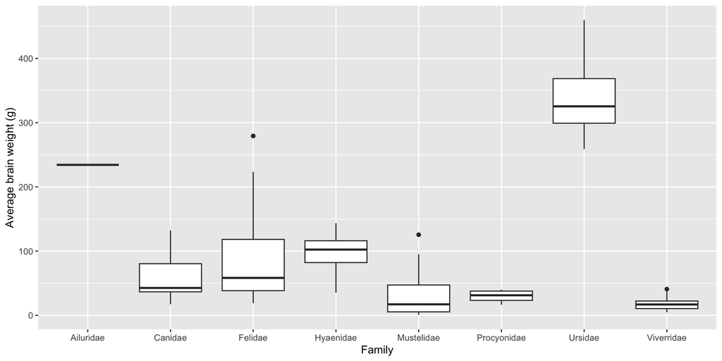

## Towards scatter plots

The most common bivariate plot is the **scatter plot**.

A scatterplot provides a case-by-case view of data for two numerical variables.

## Scatterplot, `carnivora` example

```r
ggplot(data = carnivora, aes(SW, SB)) +
    geom_point() +
    labs(x = "Average body weight (kg)",
         y = "Average brain weight (g)")
```

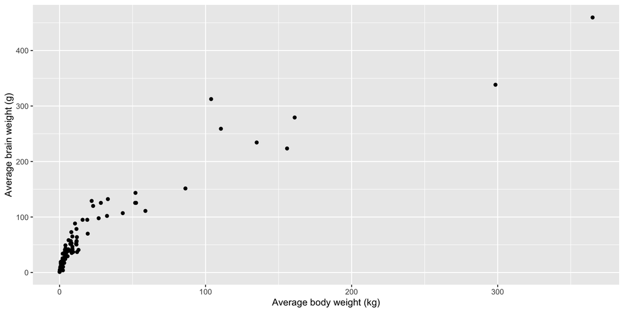

## Scatter plots, keywords

- **associated**. When two variables show some connection with one another, they are called associated variables.
- **independent**. If two variables are not associated, then they are said to be independent.

## Scatter plots, keywords

Direction of association can be described as

- **positive association**. When two variables have an upward/positive trend, they are called positively associated.
- **negative association**. When two variables have a downward/negative trend, they are called negatively associated.

## Scatter plots, keywords

Structure of association can be described as **linear** or **non-linear**.

## Scatter plot, `Indometh` example

```r
library(datasets)
# ?Indometh
ggplot(data = Indometh, aes(time, conc)) +
    geom_point()
```

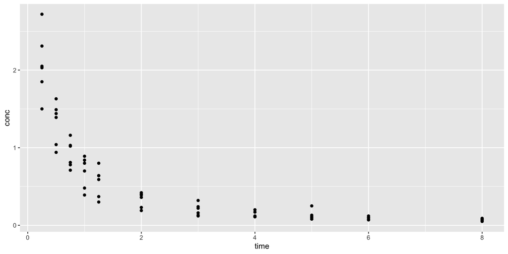

## Scatter plot, `CO2` example

```r
# ?CO2
ggplot(data = CO2, aes(conc, uptake, colour = Type)) +
    geom_point()
```

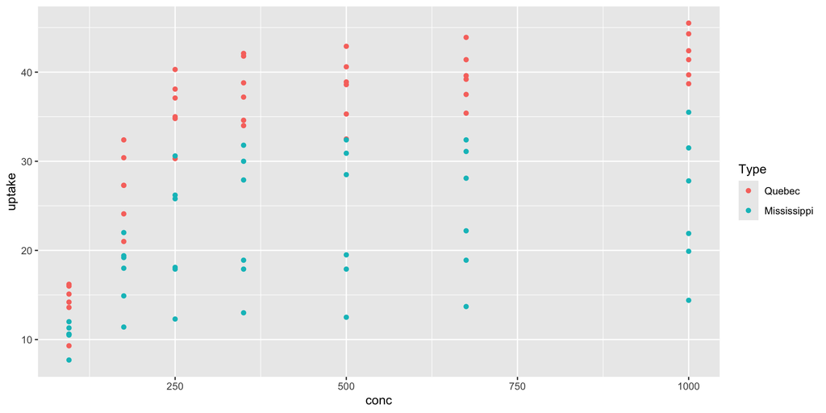

## Scatter plots, careful

```r
# x: Australian residents, quarterly 03/1971 - 03/1994
# y: WI beaver body temps, 10 min intervals
df <- data.frame(x = as.vector(austres),
                 y = beaver1[1:length(austres), "temp"])
ggplot(data = df, aes(x, y)) +
    geom_point()
```

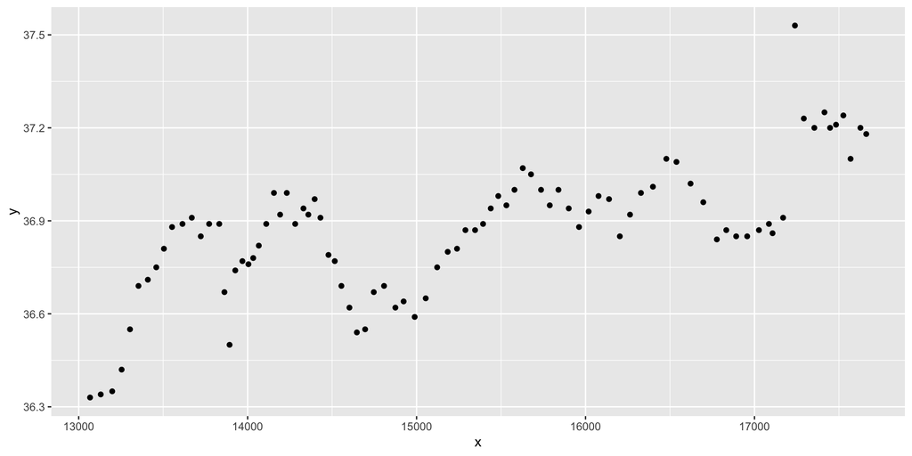

## for fun

https://xkcd.com/552/

## Take Away

- categorical variable -> bar chart
- one numerical variable -> histogram
- one numerical and one categorical -> box plot
- two numerical -> scatter plot
- … many variations